# Copy_of_customer_service

```python
# To find out distinct value  in Community Board
csr_df['CB2'].value_counts()
```

```
 BROOKLYN                    98307
 QUEENS                      80639
 MANHATTAN                   66108
 BRONX                       40702
 STATEN ISLAND               12341
 Unspecified                  2574
Unspecified MANHATTAN           23
Unspecified STATEN ISLAND        2
Unspecified QUEENS               2
Name: CB2, dtype: int64
```

```python
# the columns 'Borough' and  Community Board have similar entries, So Drop column 'Community Board'
csr_df.drop(columns= ['Community Board','CB2'], inplace=True)
csr_df
```

|  | Unique Key | Created Date | Closed Date | Agency | Agency Name | Complaint Type | Descriptor | Location Type | Incident Zip | Incident Address | ... | Resolution Description | Resolution Action Updated Date | Borough | X Coordinate (State Plane) | Y Coordinate (State Plane) | Park Facility Name | Park Borough | Latitude | Longitude | Location |
| --- | --- | --- | --- | --- | --- | --- | --- | --- | --- | --- | --- | --- | --- | --- | --- | --- | --- | --- | --- | --- | --- |
| 0 | 32310363 | 2015-12-31 23:59:45 | 2016-01-01 00:55:00 | NYPD | New York City Police Department | Noise - Street/Sidewalk | Loud Music/Party | Street/Sidewalk | 10034.0 | 71 VERMILYEA AVENUE | ... | The Police Department responded and upon arriv... | 01-01-16 0:55 | MANHATTAN | 1005409.0 | 254678.0 | Unspecified | MANHATTAN | 40.865682 | -73.923501 | (40.86568153633767, -73.92350095571744) |
| 1 | 32309934 | 2015-12-31 23:59:44 | 2016-01-01 01:26:00 | NYPD | New York City Police Department | Blocked Driveway | No Access | Street/Sidewalk | 11105.0 | 27-07 23 AVENUE | ... | The Police Department responded to the complai... | 01-01-16 1:26 | QUEENS | 1007766.0 | 221986.0 | Unspecified | QUEENS | 40.775945 | -73.915094 | (40.775945312321085, -73.91509393898605) |
| 2 | 32309159 | 2015-12-31 23:59:29 | 2016-01-01 04:51:00 | NYPD | New York City Police Department | Blocked Driveway | No Access | Street/Sidewalk | 10458.0 | 2897 VALENTINE AVENUE | ... | The Police Department responded and upon arriv... | 01-01-16 4:51 | BRONX | 1015081.0 | 256380.0 | Unspecified | BRONX | 40.870325 | -73.888525 | (40.870324522111424, -73.88852464418646) |
| 3 | 32305098 | 2015-12-31 23:57:46 | 2016-01-01 07:43:00 | NYPD | New York City Police Department | Illegal Parking | Commercial Overnight Parking | Street/Sidewalk | 10461.0 | 2940 BAISLEY AVENUE | ... | The Police Department responded to the complai... | 01-01-16 7:43 | BRONX | 1031740.0 | 243899.0 | Unspecified | BRONX | 40.835994 | -73.828379 | (40.83599404683083, -73.82837939584206) |
| 4 | 32306529 | 2015-12-31 23:56:58 | 2016-01-01 03:24:00 | NYPD | New York City Police Department | Illegal Parking | Blocked Sidewalk | Street/Sidewalk | 11373.0 | 87-14 57 ROAD | ... | The Police Department responded and upon arriv... | 01-01-16 3:24 | QUEENS | 1019123.0 | 206375.0 | Unspecified | QUEENS | 40.733060 | -73.874170 | (40.733059618956815, -73.87416975810375) |
| ... | ... | ... | ... | ... | ... | ... | ... | ... | ... | ... | ... | ... | ... | ... | ... | ... | ... | ... | ... | ... | ... |
| 300693 | 30281872 | 2015-03-29 00:33:41 | NaT | NYPD | New York City Police Department | Noise - Commercial | Loud Music/Party | Club/Bar/Restaurant | NaN | CRESCENT AVENUE | ... | Your complaint has been forwarded to the New Y... | NaN | Unspecified | NaN | NaN | Unspecified | Unspecified | NaN | NaN | NaN |
| 300694 | 30281230 | 2015-03-29 00:33:28 | 2015-03-29 02:33:59 | NYPD | New York City Police Department | Blocked Driveway | Partial Access | Street/Sidewalk | 11418.0 | 100-17 87 AVENUE | ... | The Police Department responded and upon arriv... | 03/29/2015 02:33:59 AM | QUEENS | 1026931.0 | 192185.0 | Unspecified | QUEENS | 40.694077 | -73.846087 | (40.69407728322387, -73.8460866160573) |
| 300695 | 30283424 | 2015-03-29 00:33:03 | 2015-03-29 03:40:20 | NYPD | New York City Police Department | Noise - Commercial | Loud Music/Party | Club/Bar/Restaurant | 11206.0 | 162 THROOP AVENUE | ... | The Police Department responded to the complai... | 03/29/2015 03:40:20 AM | BROOKLYN | 999713.0 | 194161.0 | Unspecified | BROOKLYN | 40.699590 | -73.944234 | (40.69959035300927, -73.94423377144169) |
| 300696 | 30280004 | 2015-03-29 00:33:02 | 2015-03-29 04:38:35 | NYPD | New York City Police Department | Noise - Commercial | Loud Music/Party | Club/Bar/Restaurant | 10461.0 | 3151 EAST TREMONT AVENUE | ... | The Police Department responded to the complai... | 03/29/2015 04:38:35 AM | BRONX | 1030021.0 | 244520.0 | Unspecified | BRONX | 40.837708 | -73.834587 | (40.8377075854206, -73.83458731019586) |
| 300697 | 30281825 | 2015-03-29 00:33:01 | 2015-03-29 04:41:50 | NYPD | New York City Police Department | Noise - Commercial | Loud Music/Party | Store/Commercial | 10036.0 | 251 WEST 48 STREET | ... | The Police Department responded to the complai... | 03/29/2015 04:41:50 AM | MANHATTAN | 988150.0 | 216378.0 | Unspecified | MANHATTAN | 40.760583 | -73.985922 | (40.76058322950115, -73.98592204392392) |

300698 rows × 28 columns

```python
# to replace all other 'Unspecified' entries as na values
csr_df.replace('Unspecified',np.NAN,inplace=True)
csr_df = csr_df.dropna(how='all')
# remove all the rows containing NA values
csr_df = csr_df[(csr_df['Latitude'].notnull())& csr_df['Longitude'].notnull()& (csr_df['Descriptor'].notnull()) ]
csr_df.nunique()
```

```
Unique Key                        291317
Created Date                      252153
Closed Date                       232128
Agency                                 1
Agency Name                            2
Complaint Type                        15
Descriptor                            41
Location Type                         14
Incident Zip                         200
Incident Address                  104602
Street Name                         6624
Cross Street 1                      5786
Cross Street 2                      5801
Address Type                           5
City                                  53
Facility Type                          1
Status                                 4
Due Date                          252500
Resolution Description                14
Resolution Action Updated Date    232868
Borough                                5
X Coordinate (State Plane)         62809
Y Coordinate (State Plane)         73038
Park Facility Name                     0
Park Borough                           5
Latitude                          123070
Longitude                         123169
Location                          123980
dtype: int64
```

**Create a new column 'Request_Closing_Time' as the time elapsed between request creation and request closing.**

```python
csr_df['Request_Closing_Time'] = csr_df['Closed Date'] - csr_df['Created Date']
```

```python
csr_df['Request_Closing_Time_Bin'] = pd.cut(csr_df['Request_Closing_Time'],100)
csr_df['Request_Closing_Time_Bin'].value_counts()
```

```
(-1 days +23:25:25.718000, 0 days 05:56:42.820000]    228777
(0 days 05:56:42.820000, 0 days 11:52:25.640000]       45164
(0 days 11:52:25.640000, 0 days 17:48:08.460000]       10223
(0 days 17:48:08.460000, 0 days 23:43:51.280000]        3410
(0 days 23:43:51.280000, 1 days 05:39:34.100000]        1465
                                                       ...
(15 days 01:39:32.020000, 15 days 07:35:14.840000]         0
(15 days 07:35:14.840000, 15 days 13:30:57.660000]         0
(15 days 13:30:57.660000, 15 days 19:26:40.480000]         0
(15 days 19:26:40.480000, 16 days 01:22:23.300000]         0
(12 days 08:26:41, 12 days 14:22:23.820000]                0
Name: Request_Closing_Time_Bin, Length: 100, dtype: int64
```

```python
csr_df.info()
```

```
<class 'pandas.core.frame.DataFrame'>
Int64Index: 291317 entries, 0 to 300697
Data columns (total 30 columns):
 #   Column                          Non-Null Count   Dtype
---  ------                          --------------   -----
 0   Unique Key                      291317 non-null  int64
 1   Created Date                    291317 non-null  datetime64[ns]
 2   Closed Date                     291261 non-null  datetime64[ns]
 3   Agency                          291317 non-null  object
 4   Agency Name                     291317 non-null  object
 5   Complaint Type                  291317 non-null  object
 6   Descriptor                      291317 non-null  object
 7   Location Type                   291205 non-null  object
 8   Incident Zip                    291277 non-null  float64
 9   Incident Address                249006 non-null  object
```

[output cut: 22 more lines]

```python
# convert Request Closing Time in Seconds
csr_df['Request_Closing_Time_Secs'] = csr_df['Request_Closing_Time'].apply(lambda x : x.seconds)
csr_df['Request_Closing_Time_Secs'] = csr_df['Request_Closing_Time_Secs']
csr_df = csr_df[csr_df['Request_Closing_Time_Secs'].notnull()]
csr_df.info()
```

```
<class 'pandas.core.frame.DataFrame'>
Int64Index: 291261 entries, 0 to 300697
Data columns (total 31 columns):
 #   Column                          Non-Null Count   Dtype
---  ------                          --------------   -----
 0   Unique Key                      291261 non-null  int64
 1   Created Date                    291261 non-null  datetime64[ns]
 2   Closed Date                     291261 non-null  datetime64[ns]
 3   Agency                          291261 non-null  object
 4   Agency Name                     291261 non-null  object
 5   Complaint Type                  291261 non-null  object
 6   Descriptor                      291261 non-null  object
 7   Location Type                   291149 non-null  object
 8   Incident Zip                    291221 non-null  float64
 9   Incident Address                248961 non-null  object
```

[output cut: 23 more lines]

**(3) Conclusions after Data Visualization**

```python
# to find the most frequent types of complaints
most_freq_complaints = csr_df.dropna(subset=["Complaint Type"])
most_freq_complaints = csr_df.groupby("Complaint Type")

sorted_ComplaintType = most_freq_complaints.size().sort_values(ascending = False)
sorted_ComplaintType = sorted_ComplaintType.to_frame('count').reset_index()

sorted_ComplaintType
sorted_ComplaintType.head(10)
```

|  | Complaint Type | count |
| --- | --- | --- |
| 0 | Blocked Driveway | 76714 |
| 1 | Illegal Parking | 74059 |
| 2 | Noise - Street/Sidewalk | 47779 |
| 3 | Noise - Commercial | 35161 |
| 4 | Derelict Vehicle | 17514 |
| 5 | Noise - Vehicle | 16871 |
| 6 | Animal Abuse | 7747 |
| 7 | Traffic | 4474 |
| 8 | Noise - Park | 3928 |
| 9 | Vending | 3775 |

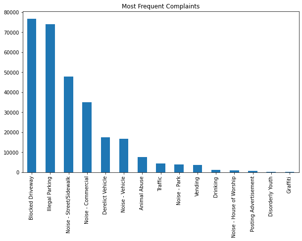

```python
# to plot the complaint types against the number of time they have occured
(csr_df['Complaint Type'].value_counts()).head(15).plot(kind='bar',figsize=(10,6),title="Most Frequent Complaints")
```

**Conclusion 1 :**

> - The most frequent complaint type recieved is about Blocked Driveway and Illegal Parking.

```python
# to understand the borough wise portion of total complaints recieved
csr_df['Borough'].value_counts()
```

```
BROOKLYN         96899
QUEENS           79833
MANHATTAN        62081
BRONX            40231
STATEN ISLAND    12217
Name: Borough, dtype: int64
```

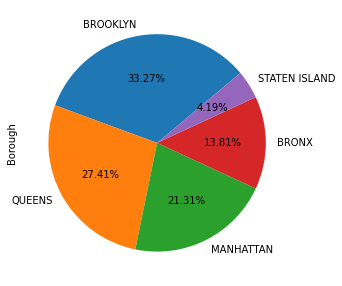

```python
# to plot a pie graph showing the Borough wise percentage of complaints recieved.
csr_df['Borough'].value_counts().plot(kind='pie',autopct='%1.2f%%',startangle=40,figsize=(10,5))
```

**Conclusion 2:**

- Borough wise, Brookyln has the most number of complaints followed by the Queens and Manhattan.

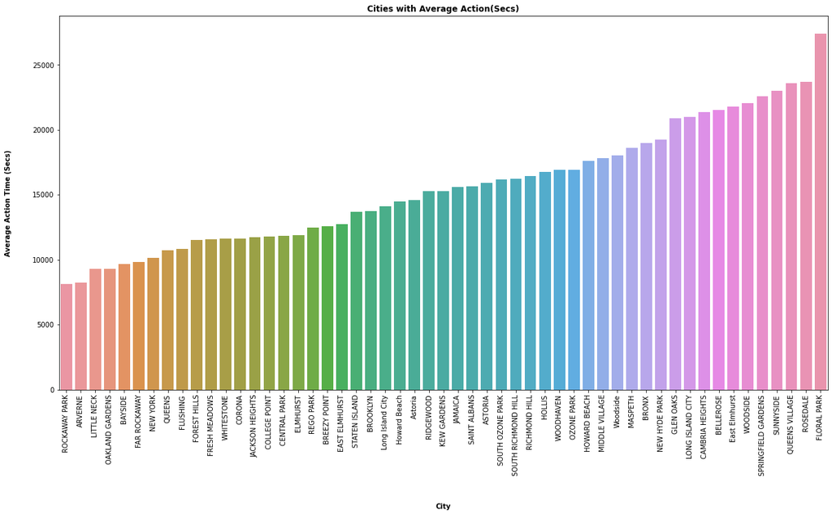

```python
city_average_action_time = csr_df[['City','Request_Closing_Time_Secs']]
city_average_action_time_1 = city_average_action_time.groupby('City')['Request_Closing_Time_Secs'].mean().to_frame()
city_average_action_time_1 = city_average_action_time_1.sort_values('Request_Closing_Time_Secs')
city_average_action_time_1['City'] = city_average_action_time_1.index
txt={'weight':'bold'}
plt.figure(figsize=(20,10))
sns.barplot(x='City',y='Request_Closing_Time_Secs', data=city_average_action_time_1)
plt.title("Cities with Average Action(Secs)",fontdict=txt)
plt.ylabel("Average Action Time (Secs)", fontdict=txt, labelpad=30 )
plt.xlabel("City", fontdict=txt, labelpad=40 )
plt.xticks(rotation=90)
plt.show()
```

**Conclusion 3:**

- Rockaway park and Arverne have minimum complaint Response time & Floral Park has maximum complaint Response time.

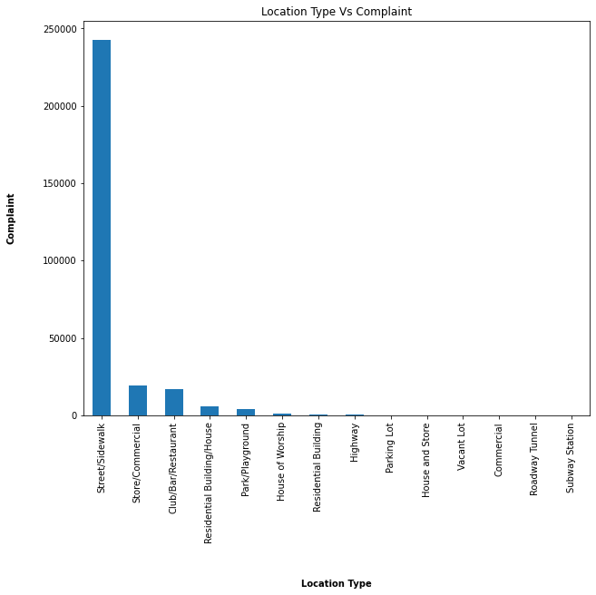

```python
#Location Type Vs Complaints
csr_df['Location Type'].value_counts().plot(kind='bar',figsize=(10,8),title='Location Type Vs Complaint')
plt.ylabel("Complaint", fontdict=txt, labelpad=30 )
plt.xlabel("Location Type", fontdict=txt, labelpad=40 )
plt.xticks(rotation=90)
plt.show()
```

**Conclusion 4 :**

- Most the Complaint are reported in Location Type 'Street/Sidewalk' followed by 'Store/Commercial'.

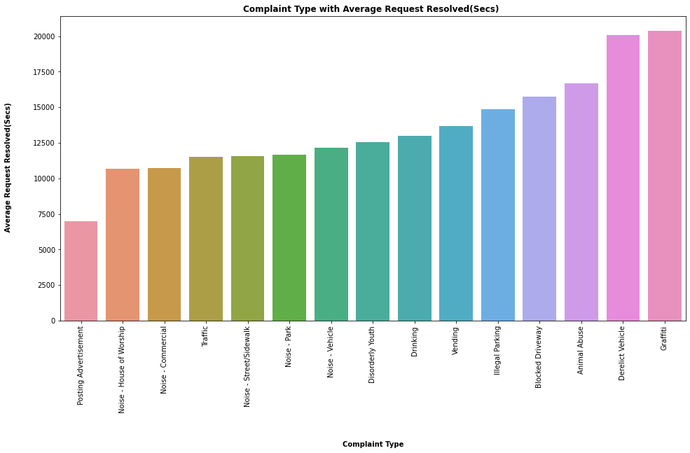

```python
#Visualizing complaint types with average response time
comp_action_time = csr_df[['Complaint Type','Request_Closing_Time_Secs']]
comp_action_time2 = comp_action_time.groupby('Complaint Type')['Request_Closing_Time_Secs'].mean().to_frame()
comp_action_time2 = comp_action_time2.sort_values('Request_Closing_Time_Secs')
comp_action_time2['Complaint Type'] = comp_action_time2.index
txt={'weight':'bold'}
plt.figure(figsize=(16,8))
sns.barplot(x='Complaint Type',y='Request_Closing_Time_Secs', data=comp_action_time2)
plt.title("Complaint Type with Average Request Resolved(Secs) ",fontdict=txt)
plt.ylabel(" Average Request Resolved(Secs)", fontdict=txt, labelpad=30 )
plt.xlabel("Complaint Type", fontdict=txt, labelpad=40 )
plt.xticks(rotation=90)
plt.show()
```

**Conclusion 5 :**

- Posting Advertisement Complaints are responded faster and Derelict Vehicle, Greffiti complaints are responded slower.

**(4) Ordering the complaint types based on the average ‘Request_Closing_Time’, grouping them for different locations.**

```python
from pandas.core.groupby.generic import DataFrameGroupBy
# Ordering the complaint types based on the average ‘Request_Closing_Time’, grouping them for different locations.
groupedby_complainttype = csr_df.sort_values('Request_Closing_Time_Secs').groupby(['Location Type','Complaint Type'])['Request_Closing_Time_Secs'].mean().to_frame()
DataFrameGroupByLocationType = pd.DataFrame(groupedby_complainttype)
DataFrameGroupByLocationType.style.set_table_styles([{'selector': 'tr', 'props': [('font-size','9pt'),('border-style','solid'),('border-width','2px')]}])
```

| Location Type | Complaint Type | Request_Closing_Time_Secs |
| --- | --- | --- |
| Club/Bar/Restaurant | Drinking | 14471.224658 |
|  | Noise - Commercial | 10402.914743 |
| Commercial | Animal Abuse | 16446.870968 |
| Highway | Derelict Vehicle | 16212.230769 |
|  | Traffic | 11947.123656 |
| House and Store | Animal Abuse | 16189.677419 |
| House of Worship | Noise - House of Worship | 10673.898913 |
| Park/Playground | Animal Abuse | 11761.100000 |
|  | Drinking | 12082.458333 |
|  | Noise - Park | 11677.570919 |
|  | Vending | 12508.728155 |
| Parking Lot | Animal Abuse | 16005.137615 |
|  | Posting Advertisement | 7616.714286 |
| Residential Building | Animal Abuse | 15844.650442 |
| Residential Building/House | Animal Abuse | 17467.388495 |
|  | Disorderly Youth | 13876.116883 |
|  | Drinking | 12942.851211 |
|  | Graffiti | 18077.964286 |
|  | Posting Advertisement | 12961.833333 |
|  | Vending | 14679.651741 |
| Roadway Tunnel | Derelict Vehicle | 30111.000000 |
|  | Traffic | 7837.379310 |
| Store/Commercial | Animal Abuse | 14908.265385 |
|  | Disorderly Youth | 10222.125000 |
|  | Drinking | 11709.344444 |
|  | Graffiti | 20018.312500 |
|  | Noise - Commercial | 11038.686505 |
|  | Posting Advertisement | 8529.000000 |
|  | Vending | 13905.817130 |
| Street/Sidewalk | Animal Abuse | 15269.866755 |
|  | Blocked Driveway | 15776.283423 |
|  | Derelict Vehicle | 20118.126299 |
|  | Disorderly Youth | 12124.830000 |
|  | Drinking | 12269.081395 |
|  | Graffiti | 26055.080000 |
|  | Illegal Parking | 14876.229142 |
|  | Noise - Street/Sidewalk | 11584.398325 |
|  | Noise - Vehicle | 12180.165876 |
|  | Posting Advertisement | 6399.410345 |
|  | Traffic | 11529.945933 |
|  | Vending | 13629.661508 |
| Subway Station | Animal Abuse | 10928.181818 |
| Vacant Lot | Derelict Vehicle | 14563.272727 |

```python
from pandas.core.groupby.generic import DataFrameGroupBy
# Ordering the complaint types based on the average ‘Request_Closing_Time’, grouping them for different Cities.
groupedby_complainttype = csr_df.sort_values('Request_Closing_Time_Secs').groupby(['City','Complaint Type'])['Request_Closing_Time_Secs'].mean().to_frame()
DataFrameGroupByLocationType = pd.DataFrame(groupedby_complainttype).head(60)
DataFrameGroupByLocationType.style.set_table_styles([{'selector': 'tr', 'props': [('font-size','9pt'),('border-style','solid'),('border-width','2px')]}])
```

| City | Complaint Type | Request_Closing_Time_Secs |
| --- | --- | --- |
| ARVERNE | Animal Abuse | 7753.052632 |
|  | Blocked Driveway | 9093.485714 |
|  | Derelict Vehicle | 10685.592593 |
|  | Disorderly Youth | 12928.500000 |
|  | Drinking | 859.000000 |
|  | Graffiti | 5520.000000 |
|  | Illegal Parking | 8338.913793 |
|  | Noise - Commercial | 8234.000000 |
|  | Noise - House of Worship | 5623.909091 |
|  | Noise - Park | 4620.000000 |
|  | Noise - Street/Sidewalk | 7172.620690 |
|  | Noise - Vehicle | 6695.571429 |
|  | Vending | 1740.000000 |
| ASTORIA | Animal Abuse | 18000.608000 |
|  | Blocked Driveway | 17206.014897 |
|  | Derelict Vehicle | 26265.914530 |
|  | Disorderly Youth | 10449.333333 |
|  | Drinking | 17000.714286 |
|  | Graffiti | 29142.250000 |
|  | Illegal Parking | 16832.938028 |
|  | Noise - Commercial | 11261.369735 |
|  | Noise - House of Worship | 7280.000000 |
|  | Noise - Park | 10782.393443 |
|  | Noise - Street/Sidewalk | 12436.763636 |
|  | Noise - Vehicle | 12633.034314 |
|  | Posting Advertisement | 21132.000000 |
|  | Traffic | 19476.659574 |
|  | Vending | 17767.500000 |
| Astoria | Blocked Driveway | 16947.836207 |
|  | Derelict Vehicle | 15250.166667 |
|  | Illegal Parking | 16555.009390 |
|  | Noise - Commercial | 12419.770115 |
|  | Noise - Street/Sidewalk | 13367.631579 |
| BAYSIDE | Animal Abuse | 11788.243243 |
|  | Blocked Driveway | 9227.058355 |
|  | Derelict Vehicle | 12095.207071 |
|  | Disorderly Youth | 10703.000000 |
|  | Drinking | 6840.000000 |
|  | Graffiti | 16385.666667 |
|  | Illegal Parking | 9208.288499 |
|  | Noise - Commercial | 8041.200000 |
|  | Noise - House of Worship | 12725.500000 |
|  | Noise - Park | 14320.000000 |
|  | Noise - Street/Sidewalk | 5511.600000 |
|  | Noise - Vehicle | 6150.312500 |
|  | Traffic | 5497.000000 |
|  | Vending | 6760.500000 |
| BELLEROSE | Animal Abuse | 33466.000000 |
|  | Blocked Driveway | 21806.305263 |
|  | Derelict Vehicle | 25886.213483 |
|  | Disorderly Youth | 6660.000000 |
|  | Drinking | 14105.000000 |
|  | Illegal Parking | 21380.311321 |
|  | Noise - Commercial | 14926.243243 |
|  | Noise - House of Worship | 7909.000000 |
|  | Noise - Park | 5091.000000 |
|  | Noise - Street/Sidewalk | 19353.307692 |
|  | Noise - Vehicle | 9299.400000 |
|  | Posting Advertisement | 8136.000000 |
|  | Traffic | 20731.857143 |

**(5) Statistical Test**

> **a) Whether the average response time across complaint types is similar or not (overall) ?**
- **Null Hypothesis: H0**: There is no significant difference in average response time across different complaint types.
  1. **Alternate hypothesis: Ha:** There is a significant difference in average response time across different complaint types.
  2. To conduct our hypothesis test, we will conduct an ANOVA (Analysis of Variance) test as we have to compare the means of more than two groups.
  3. Assumptions of ANOVA test are :
     - The samples are independent.
     - Each sample is from a normally distributed population.
     - The population standard deviations of the groups are equal.
- Since Alpha value is not given, Assume alpha value = 0.05 i.e., Testing at Confidence level (95%).

```python
# storing mean response time for various complaint types
complaint_type = csr_df['Complaint Type'].value_counts().index
for i in range(len(complaint_type)):
  exec("sample{} = csr_df.loc[(csr_df['Complaint Type'] == '{}' ), 'Request_Closing_Time_Secs']".format(i+1,complaint_type[i]))
```

```python
# Perform one-way ANOVA
fscore,pvalue = stats.f_oneway(sample1,sample2,sample3,sample4,sample5,sample6,sample7,sample8,sample9,sample10,sample11,sample12,sample13,sample14,sample15)
print("fscore: {:.2f}, pvalue:{:.2f}".format(fscore,pvalue))
```

```
fscore: 691.51, pvalue:0.00
```

**pvalue(0.00) < alpha value(0.05)**

- So we REJECT our NULL HYPOTHESIS (NULL HYPOTHESIS : H0 : There is no significant difference in average response time across different complaint types
- Hence there is a significant difference in average response time across different complaint types.

**i.e., The average response time across different complaint types is not simlar (overall).**

**b) Are the type of complaint or service requested and location related?**

- Here we are using **Chi-Square Test of Independence**
  - Since Alpha value is not given, Assume alpha value = 0.05 i.e., Testing at Confidence level (95%)
  - **NULL HYPOTHESIS** : H0 : There is no significant relation between type of complaint and location.
  - **Alternate HYPOTHESIS** : Ha : There is some significant relation between type of complaint and location.

```python
# Chi-Square test of independence
Chi_sq_complaint_Location_type = pd.crosstab(csr_df['Complaint Type'],csr_df['Location'])
```

```python
from  scipy import stats
chisq,pval,df,et = stats.chi2_contingency(Chi_sq_complaint_Location_type)
print("chisq Score : {:.2f}, pvalue : {:.3f}".format(chisq,pval))
```

```
chisq Score : 3104085.04, pvalue : 0.000
```

**pvalue(0.00) < alpha value(0.05)**

- So we REJECT our NULL HYPOTHESIS (NULL HYPOTHESIS : H0 : There is no significant relation between type of complaint and location)
- Hence there is a significant relation between type of complaint and location.

> **i.e., The type of complaint or service requested and the location are related.**